# 《乘风破浪的姐姐》多平台话题传播情况分析

狗熊会

案例背景： 《乘风破浪的姐姐》是2020年夏天一档聚焦“30+”女艺人的爆款女团选秀类综艺。在一亿人聚焦的目光下，姐姐们有的微博涨粉百万，有的登上网络评选恶人榜。在姐姐们风评变化的过程中，公关公司起着处理危机事件、包装形象、打造话题的重要作用。事实上，成功的公关传播依赖于对传播渠道的深入洞悉。因此对不同平台的传播特点的分析具有重要的意义。本案例以微博、豆瓣、知乎三大平台为代表，分析《乘风破浪的姐姐》在不同平台的话题传播特点。案例的详细背景请参考推文[《乘风破浪的姐姐》多平台话题传播情况分析](https://mp.weixin.qq.com/s/iq3jbn8Y8-myptBcGygV7g)

这个案例的学习目标包括：

1.学习如何分析不同平台的话题传播特点

2.了解基本的公关知识，学习如何分析传播平台的意见领袖影响力

3.学习如何对周期型数据进行时间序列建模和预测

## 准备工作

```r
##清除工作环境
cat("\014");rm(list=ls())
```

```r
##加载程序包
library(readxl)    # 用于加载excel文件
library(ggplot2)   # 用于绘图
library(stringr)   # 用于进行字符串处理
library(tseries)   # 用于时间序列分析
library(forecast)  # 用于时间序列预测
library(dplyr)     # 用于数据整合
library(knitr)     # 美化表格
library(ggpubr)    # 用于将多张图绘制在一起
```

## 任务一

数据读入。请阅读readme.txt了解各个数据表的含义以及数据中包含的变量信息。这个任务重点关注不同平台的话题热度分析，所以请分别读入豆瓣、微博、知乎三个平台的数据，即doubancom.xlsx、wbcom.xlsx、zhihucom.xlsx三个数据表。然后使用as.Date()命令将三个数据中的时间变量转变为标准的时间格式。最后，使用head()展示三个数据的基本情况。

```r
##使用read_excel导入xlsx格式文件
doubancom<-read_excel('doubancom.xlsx')
wbcom<-read_excel('wbcom.xlsx')
zhihucom<-read_excel('zhihucom.xlsx')

##将时间变量转化为标准的时间格式
doubancom$time<-as.Date(doubancom$time)
wbcom$time<-as.Date(wbcom$time)
zhihucom$time<-as.Date(zhihucom$time)

##展示三个平台的数据情况
head(doubancom)
```

```
## # A tibble: 6 x 5
##   ID       short                                   votes time       emotion
##   <chr>    <chr>                                   <chr> <date>       <dbl>
## 1 阿丘     芒果能出个无杜华版吗？她影响了我看喜剧的好心情。… 6777  2020-06-12 0.00252
## 2 蓝色的椰子… 宁静:还要我介绍我是谁？我这几十年都白干了。… 5107  2020-06-12 0.134
## 3 你知不知道… 姐姐比妹妹的搞头可多太多了！            4324  2020-06-12 0.771
## 4 徐若风   初观感：脑子以每7分钟1热搜的脑补速度运转… 3566  2020-06-12 0.967
## 5 HarperY… 宁静：这么多娘们在一起怎么办！xswl-     3393  2020-06-12 0.865
## 6 北copy   你好歹等热搜回来了再播嘛！这样悄没声地播得赔多少钱啊！芒果请你有点心！… 3014  2020-06-12 0.0107
```

```r
head(wbcom)
```

```
## # A tibble: 6 x 5
##   ID        content                                time       agree emotion
##   <chr>     <chr>                                  <date>     <chr>   <dbl>
## 1 明星神秘人… #蓝盈莹加入宁静组姐姐们的反应#期待新的姐姐组合会有不同的精彩啦！#乘风破… 2020-07-31 1       1.000
## 2 明星神秘人… #新物种舞台##新物种组第一##万茜##李斯丹妮##金晨##黄龄##袁咏琳… 2020-07-31 10      1.000
## 3 ·知名收藏家·… #乘风破浪的姐姐们##乘风破浪的姐姐##乘风破浪的姐姐们##乘风破浪的姐姐… 2020-07-31 0       0.999
## 4 KOOOI可以饰… #早安#保持对生活的爱和热情，把每一天都活的热气腾腾#乘风破浪的姐姐们# … 2020-07-31 1       1.000
## 5 半陌白    #乘风破浪的姐姐们# 二公×三公舞台二公我可太喜欢中间的舞台了！疼痛，动物… 2020-07-30 0       0.993
## 6 逸凡优雅  #乘风破浪的姐姐们#我家宝非要问我每个姐姐名字，我能认出来吗？每个姐姐都长… 2020-07-30 1       0.900
```

```r
head(zhihucom)
```

```
## # A tibble: 6 x 6
##   ID     tag            agree time       comment                    emotion
##   <chr>  <chr>          <chr> <date>     <chr>                        <dbl>
## 1 果藏   低欲望年轻一代 1066  2020-07-31 就会整些花里胡哨的东西来恶心人,观众烦，姐姐们也烦… 7.97e-5
## 2 古承阳 称孤道寡单身狗，抱残守缺直… 1850  2020-08-03 这段分析带来的反馈很多，着实超乎了我最初的预想，尤… 5.28e-1
## 3 灰山   保持理智，共勉 2334  2020-08-01 1.黄圣依跟丁当是真的结仇了,这么多期都念念不忘，… 4.25e-3
## 4 <NA>   <NA>           127   2020-08-01 宁静呵呵的其实不是winwin，而是节目组。,一个… 8.67e-1
## 5 莲仙字 微博莲仙小字，转载需授权，… 2867  2020-08-01 宁静组唱的《傲娇》，歌词没有放出来，明明是中文歌词… 7.24e-1
## 6 林衍燃 谢谢大家       124   2020-08-06 今天只看开心的，盘一遍姐姐们的沙雕日常和各组高光瞬… 9.53e-1
```

## 任务二

各平台热度分析。在公共关系领域，把握舆论热度的变化至关重要。由于各个平台的规则和目标用户存在很大差异，各个平台对于同一话题的热度变化也存在不同的特征。所以需要对不同平台的热度变化特征分别进行分析。

为了考察不同平台的话题热度情况，你需要绘制三个平台的评论时间密度图，并根据密度图的信息尝试分析三平台的热度变化特点。

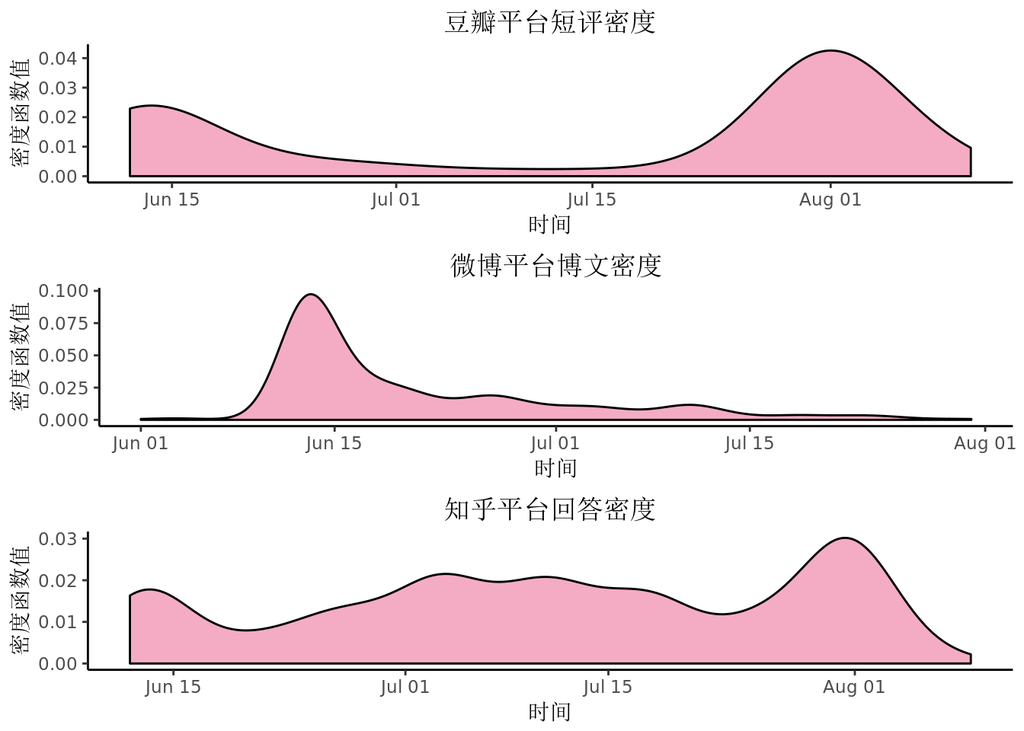

```r
##使用ggplot画出密度函数图
doubanplot<-ggplot(doubancom,aes(x=time))+geom_density(fill='#f4acc4')+xlab('时间')+ylab('密度函数值')+theme_classic()+
  ##设置标题和标题位置
  ggtitle("豆瓣平台短评密度") +theme(plot.title = element_text(hjust = 0.5))

##将ggplot对象赋值给wbplot,方便之后调用
wbplot<-ggplot(wbcom,aes(x=time))+geom_density(fill='#f4acc4')+xlab('时间')+ylab('密度函数值')+theme_classic()+ggtitle("微博平台博文密度") +theme(plot.title = element_text(hjust = 0.5))

##将ggplot对象赋值给zhihuplot,方便之后调用
zhihuplot<-ggplot(zhihucom,aes(x=time))+geom_density(fill='#f4acc4')+xlab('时间')+ylab('密度函数值')+theme_classic()+ggtitle("知乎平台回答密度") +theme(plot.title = element_text(hjust = 0.5))

## 使用"ggpubr"包内的函数将三张图绘制在一起
ggarrange(doubanplot,wbplot,zhihuplot,nrow=3)
```

#### 解读参考：

1、豆瓣平台中，6月中旬“浪姐”首播时短评数量剧增，达到一个小高峰，之后30天内迅速下降。在7月15日左右热度重新升高，在8月1日左右达到全局峰值。这可能是因为豆瓣作为评分平台，评论星级具有影响力，因此情感变化尤为剧烈。

2、微博讨论热度自开播后持续下滑。这可能是因为微博是一个以“来微博看新鲜事”为口号的平台，最新鲜的“料”已经成了这个平台的灵魂。因此微博热度来得凶猛去得也快

3、知乎回答量波动式上涨，“一浪高过一浪”。这可能是因为知乎是一个注重思考、推理、逻辑的问答型社区，丰富的回答内容给讨论提供了充分的讨论基础，观点的碰撞、融合、对立在这里不断发生。这也就使得话题能够不断发酵。

## 任务三

意见领袖影响力分析。“意见领袖”是指在群体中具有一定的话语权、在一定程度上能够影响多数人态度倾向的个体，其来自于“大众传播—意见领袖—一般受众”的经典传播模式。一个用户是否为意见领袖可以由其“被关注数”来衡量，用户的被关注数越多，说明该用户在平台上的传播力越强，因此越有可能成为意见领袖。与此同时，一个用户的影响力可以由其“点赞数”来衡量。

在这一任务中，请利用豆瓣短评、热门微博和知乎回答的点赞数，以及对应信息发布者的被关注数，来分析三个平台上意见领袖的影响力特点。具体来说，首先你需要读入各个平台的相关数据，分别为doubanrp.xlsx、wbrp.xlsx、zhrp.xlsx。其次，你可以尝试绘制各个平台上用户的被关注数和被点赞数的散点图来观察不同平台上意见领袖的影响力特点。最后，你可以通过计算被关注数和被点赞数的相关性及其显著性，来辅助判断。

```r
##读入用于进行意见领袖领导力分析的数据
doubanleader<-read_excel('doubanrp.xlsx')
wbleader<-na.omit(read_excel('wbrp.xlsx'))
zhihuleader<-na.omit(read_excel('zhrp.xlsx'))

##对三个平台点赞数和关注数数据做相关性检验
doubancor<-cor.test(doubanleader$agreenum,doubanleader$follower)
wbcor<-cor.test(wbleader$agreenum,wbleader$follower)
zhihucor<-cor.test(zhihuleader$agreenum,zhihuleader$follower)
##利用cor.test的结果绘制表格
p<-c(doubancor[["p.value"]],wbcor[["p.value"]],zhihucor[["p.value"]]) # 提取p值数据
cor<-c(doubancor[["estimate"]],wbcor[["estimate"]],zhihucor[["estimate"]]) #提取相关系数数据
platform<-c('豆瓣平台','微博平台','知乎平台') #输入平台名
corexhi<-data.frame(platform,round(p,4),round(cor,4))
names(corexhi)<-c('平台','相关性检验p值','相关系数')
##展示三个平台相关性检验结果
corexhi
```

```
##       平台 相关性检验p值 相关系数
## 1 豆瓣平台        0.0000   0.1747
## 2 微博平台        0.0000   0.2892
## 3 知乎平台        0.7926  -0.0128
```

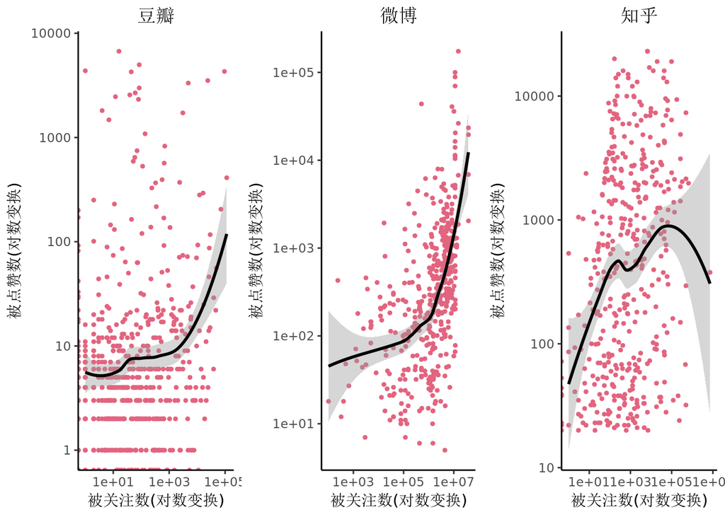

```r
##使用ggplot绘制豆瓣平台被关注数和被点赞数的散点图
doubanplot2<-ggplot(doubanleader,aes(x=follower,y=agreenum))+geom_point(size = 0.9,color='#e2647f')+xlab('被关注数(对数变换)')+ylab('被点赞数(对数变换)')+theme_classic()+ylim(0,7500)+xlim(0,20000)+
  #对x轴坐标和y轴坐标取对数，使自变量和因变量之间的相关关系更加明显
  scale_x_log10()+scale_y_log10()+geom_smooth(color=1)+labs(title="豆瓣")+theme(plot.title = element_text(hjust = 0.5))

##使用ggplot绘制微博平台被关注数和被点赞数的散点图
wbplot2<-ggplot(wbleader,aes(x=follower,y=agreenum))+geom_point(size = 0.9,color='#e2647f')+xlab('被关注数(对数变换)')+ylab('被点赞数(对数变换)')+theme_classic()+ylim(0,5000)+xlim(0,15000000)+scale_x_log10()+scale_y_log10()+
  #使用geom_smooth函数加上趋势线
  geom_smooth(color=1)+labs(title="微博")+theme(plot.title = element_text(hjust = 0.5))

##使用ggplot绘制知乎平台被关注数和被点赞数的散点图
zhihuplot2<-ggplot(zhihuleader,aes(x=follower,y=agreenum))+geom_point(size = 0.9,color='#e2647f')+xlab('被关注数(对数变换)')+ylab('被点赞数(对数变换)')+theme_classic()+ylim(0,10000)+xlim(0,50000)+scale_x_log10()+scale_y_log10()+geom_smooth(color=1)+labs(title="知乎")+theme(plot.title = element_text(hjust = 0.5))

## 使用"ggpubr"包内的函数将三张图绘制在一起
ggarrange(doubanplot2,wbplot2,zhihuplot2,ncol=3)
```

#### 解读参考：

1、从上面的结果中可以看出豆瓣平台被点赞数和被关注数成正相关(相关系数=0.175)，说明豆瓣平台意见领袖影响力较低。豆瓣平台虽然也推送用户关注对象的评论，但并未对高关注用户进行重点推广，豆瓣平台点赞行为仍旧是内容驱动的，而非意见领袖影响力驱动的。而造成豆瓣平台意见领袖影响力仍存在的原因可能是是单一化的用户人群。

2、从上面的结果中可以看出微博平台被点赞数和被关注数成正相关(相关系数=0.29)，说明微博平台意见领袖影响力较高。这可能是因为微博给高影响力用户有特殊的标志认证，首页也会优先推送已关注用户的博文。同时，由于微博“追求新料”的特点明显，新料资讯即是话语权的重要组成部分。而高关注度用户往往垄断着资讯的来源。

3、从上面的结果中可以看出知乎平台被点赞数和被关注数没有明显线性相关关系。这可能是因为这可能是因为作为一个问答型社区，知乎平台的信息流推荐机制是以“问题”为中心的，已关注用户内容的推荐权重较低

## 任务四

情感分析。网络舆论的情绪变化是公关行业非常重要的关注内容。通过对舆论情绪变化的分析有助于公关公司预判舆论风向的转变，提前一步做好公关准备。在数据doubancom.xlsx、wbcom.xlsx、zhihucom.xlsx中，我们通过调用百度情感分析的API接口，计算了每篇文档的情感得分。在这个任务中，需要你首先计算每个平台每天的情感得分均值，然后绘制时序图进行比较。

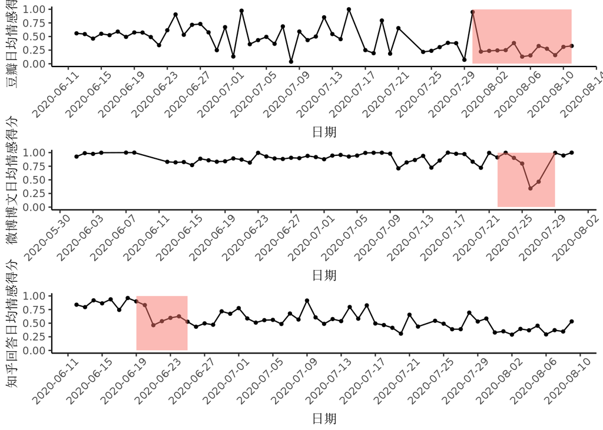

```r
##豆瓣情感分析时序图
polly<-data.frame(x = as.Date(c('2020-07-30','2020-07-30','2020-08-11','2020-08-11')),y = c(1,0,0,1))    #polly用来存储图中红色方框的四点坐标
##用summarise函数求当天情感得分平均值
doubanplot3<-doubancom%>%group_by(time)%>%summarise(emos=mean(emotion))%>%
  ggplot(aes(x=time,y=emos))+geom_point(size=1)+
  ##x坐标轴刻度每隔四天显示一个
  scale_x_date(breaks="4 days")+
  geom_line()+theme_classic()+labs(x='日期',y='豆瓣日均情感得分')+
  ##调整x坐标轴刻度的倾斜角度
  theme(axis.text.x = element_text(angle = 45, hjust = 0.85, vjust = 0.9))+
  ##画出指定位置的红色方框
  geom_polygon(data=polly,aes(x=x,y=y,fill='red'),inherit.aes=FALSE,show.legend = FALSE,alpha=0.5)

polly2<-data.frame(x = as.Date(c('2020-07-22','2020-07-22','2020-07-29','2020-07-29')),y = c(1,0,0,1))
wbplot3<-wbcom%>%group_by(time)%>%summarise(emos=mean(emotion))%>%
  ggplot(aes(x=time,y=emos))+geom_point(size=1)+
  scale_x_date(breaks="4 days")+
  geom_line()+
  theme_classic()+labs(x='日期',y='微博博文日均情感得分')+
  theme(axis.text.x = element_text(angle = 45, hjust = 0.85, vjust = 0.9))+
  geom_polygon(data=polly2,aes(x=x,y=y,fill='red'),inherit.aes=FALSE,show.legend = FALSE,alpha=0.5)

polly3<-data.frame(x = as.Date(c('2020-06-19','2020-06-19','2020-06-25','2020-06-25')),y = c(1,0,0,1))
zhihuplot3<-zhihucom%>%group_by(time)%>%summarise(emos=mean(emotion))%>%
  ggplot(aes(x=time,y=emos))+geom_point(size=1)+
  scale_x_date(breaks="4 days")+
  geom_line()+
  theme_classic()+labs(x='日期',y='知乎回答日均情感得分')+
  theme(axis.text.x = element_text(angle = 45, hjust = 0.85, vjust = 0.9))+
  geom_polygon(data=polly3,aes(x=x,y=y,fill='red'),inherit.aes=FALSE,show.legend = FALSE,alpha=0.5)

## 使用"ggpubr"包内的函数将三张图绘制在一起
ggarrange(doubanplot3,wbplot3,zhihuplot3,ncol=1,nrow=3)
```

#### 解读参考：

1、豆瓣平台日平均情感得分前期整体走势在0.5上下波动，7月30号之后评论内容的态度非常消极。后期得分走低的原因是第八期节目播出后平台涌入大量关于“皇族/万皇/万茜”的负面评论，和其他时段形成鲜明对比，不排除第三方购买水军刷评论的可能。

2、微博平台日平均情感得分前期整体走势在0.9上下波动，7月24号后一段时间评论平均情感得分“大跳水”。7月24号得分“大跳水”的原因是第七期中唱跳俱佳的前女团成员孟佳惨遭淘汰，因此在网络上引发了大众对节目组赛制和公平性的质疑。

3、知乎平台日平均情感得分前期整体走势在0.8上下波动，6月19号之后得分明显降低，后期整体走势在0.5上下波动。6月19号得分明显降低的原因是第二期中“艾瑞巴蒂”一组中丁当作为队长的领导能力备受质疑，黄圣依“实力不足却语气强势”、刘芸“瞎附和”、张雨绮“咋咋呼呼”也都成为网友诟病的点。

## 任务五

对情绪走势进行建模。由于节目的播出具有周期性，每期节目的播出都会带来新的讨论话题，因此三平台的情绪得分也呈现出了周期性的特点。为了更好的刻画序列中的周期性，并对未来的情绪走势进行预测，可以尝试使用时间序列方法进行建模。具体来说，考虑到周期性的特征，可以选择使用Holt-Winters三参数指数平滑模型对各个平台的情绪得分进行建模和预测。

在Holt-Winters三参数指数平滑模型中有三个控制参数：alpha，beta和gamma，分别对应水平效应、趋势效应和季节效应的波动幅度，也就是当期值对下期的影响。alpha，beta和gamma取值越大，说明当期值对下期值的影响越大。采用Holt-Winters对三个平台的数据建模，然后输出模型对alpha、beta和gamma的估计结果，并进行解读。

```r
##对每天的平均情感得分进行统计
doubancom_emo<-doubancom%>%group_by(time)%>%summarise(emos=mean(emotion))
##将数据类型变为时间序列（周期为7天）
doubancom_ts<-ts(doubancom_emo[,2],frequency=7)
##使用指数平滑模型
douban.fit<-HoltWinters(doubancom_ts,seasonal = 'additive')
##提取模型结果中的alpha，beta和gamma
doubanwin<-c(douban.fit[['alpha']],douban.fit[['beta']],douban.fit[['gamma']])

##对微博平台进行建模
wb_emo<-wbcom%>%group_by(time)%>%summarise(emos=mean(emotion))
wb_ts<-ts(wb_emo[,2],frequency=7)
wb.fit<-HoltWinters(wb_ts,seasonal = 'additive')
wbwin<-c(wb.fit[['alpha']],wb.fit[['beta']],wb.fit[['gamma']])

##对知乎平台进行建模
zhihu_emo<-zhihucom%>%group_by(time)%>%summarise(emos=mean(emotion))%>%na.omit()
zhihu_ts<-ts(zhihu_emo[,2],frequency=7)
zhihu.fit<-HoltWinters(zhihu_ts,seasonal = 'additive')
zhihuwin<-c(zhihu.fit[['alpha']],zhihu.fit[['beta']],zhihu.fit[['gamma']])

##汇总参数估计结果
winexhi<-round(data.frame(doubanwin,wbwin,zhihuwin),3)
##对于数据框进行重命名
names(winexhi)<-c('豆瓣平台','微博平台','知乎平台')
##展示三个平台holt-winter模型输出参数情况
winexhi
```

```
##       豆瓣平台 微博平台 知乎平台
## alpha    0.016    0.598    0.369
## beta     1.000    0.018    0.063
## gamma    0.000    0.191    0.478
```

#### 解读参考：

1、从上表中可以看到豆瓣平台beta的值为1，gamma值和alpha值极小。说明当期的趋势效应对下期平滑值的非常大，当期季节效应和水平对下期平滑值的影响非常小。

2、微博平台alpha的值最大，gamma的值偏小，beta值极小。说明当期的水平效应对下期平滑值的影响较大，当期季节效应对下期平滑值的影响较小，当期趋势效应对下期平滑值的影响非常小。

3、知乎平台gamma的值最大，alpha的值偏小，beta值极小。说明当期的季节效应对下期平滑值的影响较大，当期水平效应对下期平滑值的影响较小，当期趋势效应对下期平滑值的影响非常小。对照知乎平台情感得分时序图，大部分时刻情感得分的趋势变动都十分平缓。

## 任务六

对情绪走势进行预测。使用上一个任务中建立的Holt-Winters指数平滑模型对三个平台的未来10天的情绪得分进行预测，并尝试进行解读。

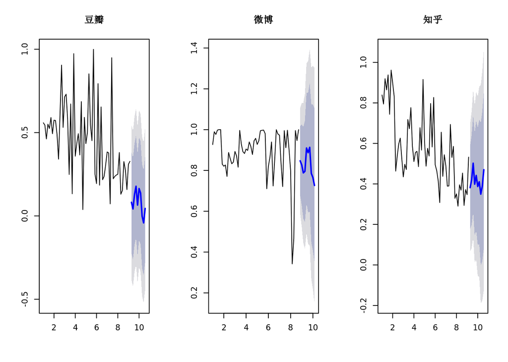

```r
##对绘图区域进行切分
par(mfrow=c(1,3))
##画出预测图
plot(forecast(douban.fit,h=10),main="豆瓣")
plot(forecast(wb.fit,h=10),main="微博")
plot(forecast(zhihu.fit,h=10),main="知乎")
```

#### 解读参考：

1、豆瓣平台舆论情绪在未来10天内总体上将进一步恶化。但是过程中会出现小幅波动。

2、微博平台舆论情绪在未来3天内会发生轻微恶化。但是3天之后舆论情绪会出现回升，总体仍然保持在0.8左右的高分。

3、知乎平台舆论情绪在未来10天内会经历一个小的回升，情感得分会在0.4左右波动。